# vignette

Francesca Lo Bianco

2025-07-23

## setting the working directory

## extracting and loading the datasets provvided

gtf_path <-“Homo_sapiens.GRCh38.111.gtf.gz” gtf <- read.delim(gzfile(gtf_path), header = FALSE, comment.char = “#”)

unzip(“filtered_feature_bc_matrix.zip”,exdir = “filtered_feature_bc_matrix”)

## installing DropletUtils to extract the features

if (!requireNamespace(“DropletUtils”, quietly = TRUE)) { BiocManager::install(“DropletUtils”) } library(DropletUtils)

## setting the path to matrix folder to read the features

matrix_dir <-“filtered_feature_bc_matrix/filtered_feature_bc_matrix” sce <- read10xCounts(matrix_dir)

## checking everything

sce

# 1.Gene Annotation: Identify and retain only the protein-coding genes from the dataset, based on the GTF file.

## creating a table for gtf

gtf <-read.table(gzfile(“C:/Users/Utente/Desktop/magistrale/programming/exam/Homo_sapiens.GRCh38.111.gtf.gz”), header = FALSE, sep = “, comment.char =”#“, stringsAsFactors = FALSE, quote =”“)

head(gtf)

## creating a function to estract the characteristics of the genes fromthe 9th column

library(stringr)

extract_characteristics <- function(attr_string, key) { pattern <- paste0(key, ” “([^\”]+)”“) match <- regmatches(attr_string, regexec(pattern, attr_string)) sapply(match, function(x) if(length(x) > 1) x[2] else NA) }

## extracting id and biotype in their column

gtf$gene_id <- extract_characteristics(gtf$V9, “gene_id”) gtf$gene_biotype <- extract_characteristics(gtf$V9,“gene_biotype”)

## finding the protein coding genes making it searchig in the gene biotype column

protein_coding_genes <- unique(gtf$gene_id[gtf$gene_biotype == “protein_coding”])

## creating a matrix only with the protein coding genes

filtered_matrix <- sce[rownames(sce) %in% protein_coding_genes, ]

## cheking it worked

ls() class(sce) dim(sce) dim(filtered_matrix)

# 2.Gene Expression Summary:For each cell, calculate the number of genes with expression ≥3 UMIs. Display the distribution of these counts using a violin plot.

## calculating the counts to create a sparse matrix

library(SingleCellExperiment) counts_matrix <- counts(sce)

## selecting only the genes with expression ≥3 UMIs

genes_over_3 <-colSums(counts_matrix >= 3)

## checking it worked

summary(genes_over_3)

## getting the ggplot2 library to create the plot

library(ggplot2)

## converting to data frame for plotting

df <- data.frame(GenesOver3UMI = genes_over_3)

## violin plot

ggplot(df, aes(x = ““, y = GenesOver3UMI)) + geom_violin(fill =”blue”, alpha = 0.6) + geom_boxplot(width = 0.1, outlier.shape = NA) + labs( title = “Number of Genes with ≥3 UMIs”, y = “Genes with ≥3 UMIs”, x = “” ) + theme_minimal(12)

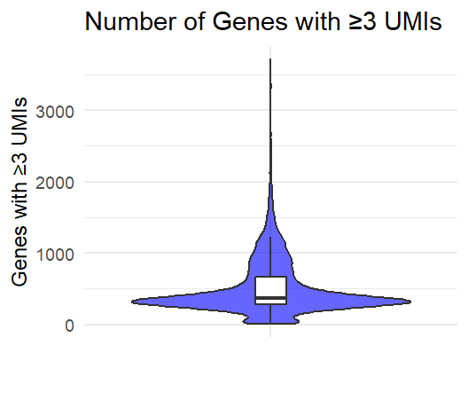

violin plot

# 3.Gene Filtering:Exclude the following gene categories:Ribosomal proteins, Ribosomal pseudogenes, Mitochondrial genes. Provide a summary table listing the number of genes removed from each category.

## creting a gene name column to identify the family of the genes

gtf$gene_name <- extract_characteristics(gtf$V9, “gene_name”)

## finding ribosomal proteins: gene names starting with “RPS” or “RPL”

ribosomal_proteins <-unique(gtf$gene_id[grepl("^RP[SL]", gtf$gene_name)])

## finding ribosomal pseudogenes: gene_type contains “pseudogene” and name starts with RPS or RPL

ribosomal_pseudogenes <- unique(gtf$gene_id[grepl("^RP[SL]", gtf$gene_name) & grepl(“pseudogene”,gtf$gene_biotype) ])

## finding mitochondrial genes: gene names starting with “MT-”

mitochondrial_genes <- unique(gtf$gene_id[grepl("^MT-", gtf$gene_name)])

## creating the summary table with all the genes found

all_genes_to_remove <- unique(c(ribosomal_proteins, ribosomal_pseudogenes, mitochondrial_genes)) summary_table <- data.frame( Category =c(“Ribosomal Proteins”, “Ribosomal Pseudogenes”, “Mitochondrial Genes”),Genes_Removed = c(length(ribosomal_proteins),length(ribosomal_pseudogenes), length(mitochondrial_genes)) )

print(summary_table)

## filtereing them out

valid_genes <- !is.na(rownames(counts_matrix)) filtered_matrix <- counts_matrix[ valid_genes &!(rownames(counts_matrix) %in% all_genes_to_remove),]

## cheking

dim(sce) dim(filtered_matrix)

|  | categories | genes removed |
| --- | --- | --- |
| **1** | Ribosomal Proteins | 1732 |
| **2** | Ribosomal Pseudogenes | 1614 |
| **3** | Mitochondrial Genes | 37 |

# 4.Principal Component Analysis (PCA):Assess the variance explained bythe first 20 principal components and visualize this using a histogram.

install.packages(“BiocManager”) BiocManager::install(c(“DropletUtils”,“scater”,“scran”,“SingleCellExperiment”)) a library(DropletUtils) library(scater) library(SingleCellExperiment)

## normalising the data

sce <- logNormCounts(sce)

## running PCA

sce <- runPCA(sce)

## calculating the variance explained by each PC

var_explained <-attr(reducedDim(sce, “PCA”), “percentVar”)

## ploting histogram of the first 20 PCs

barplot(var_explained[1:20], names.arg = 1:20, xlab = “Principal Component”, ylab = “Percentage of Variance Explained”, main = “Variance Explained by First 20 PCs”, col = “red”)

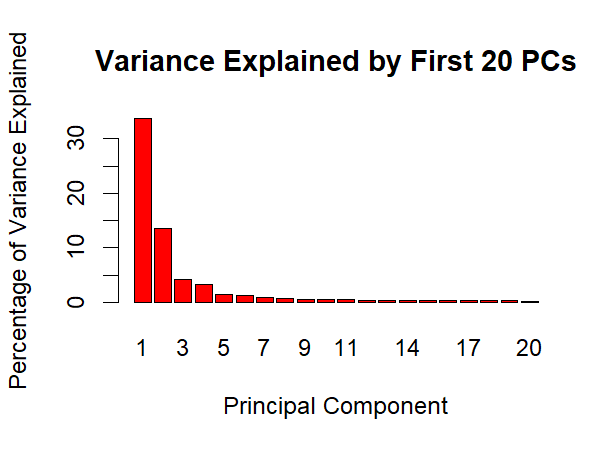

pca

# 5.UMAP Visualization:Generate a UMAP using a subset of principal components you think are sufficiently informative. Justify your choice of components in the report.

## visualising the variance to choose the subset

var_explained

## deciding on the 6th componment since it is the last higher than 1

## running the UMAP

BiocManager::install(c(“scater”, “scran”)) a library(scater) sce <- runUMAP(sce, dimred = “PCA”, n_dimred = 6)

library(ggplot2) umap_coords <- as.data.frame(reducedDim(sce, “UMAP”)) colnames(umap_coords) <- c(“UMAP1”, “UMAP2”)

## plotting the UMAP

ggplot(umap_coords, aes(x = UMAP1, y = UMAP2)) + geom_point(size = 0.3, alpha = 1) + labs(title = “UMAP Based on First 6 Principal Components”) + theme_minimal(12)

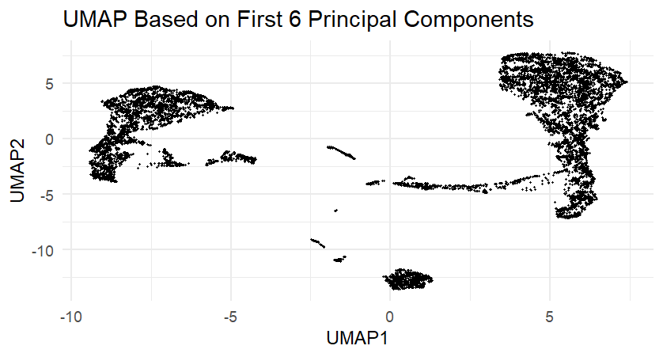

umap

# 6.Clustering:Apply a clustering algorithm of your choice and visualize the clusters. Clearly describe:The clustering method used, Parameters and resolution settings, Interpretation of the resulting clusters.Building shared nearest neighbor graph

library(SingleCellExperiment) library(scran) library(scater) library(igraph) snn_graph <-buildSNNGraph(sce, use.dimred = “PCA”, k = 10)

## clustering with the Walktrap algorithm

clusters <- igraph::cluster_walktrap(snn_graph)$membership

## storing clusters in sce

colLabels(sce) <- factor(clusters)

umap_df <- as.data.frame(reducedDim(sce, “UMAP”)) umap_df$Cluster <- colLabels(sce)

## plotting the UMAP based on the clusters found

library(ggplot2) ggplot(umap_df, aes(x = UMAP1, y = UMAP2, color = Cluster)) + geom_point(size = 0.3, alpha = 1) + labs(title = “UMAP Colored by Clusters (Walktrap, k=10)”) + theme_minimal(10)

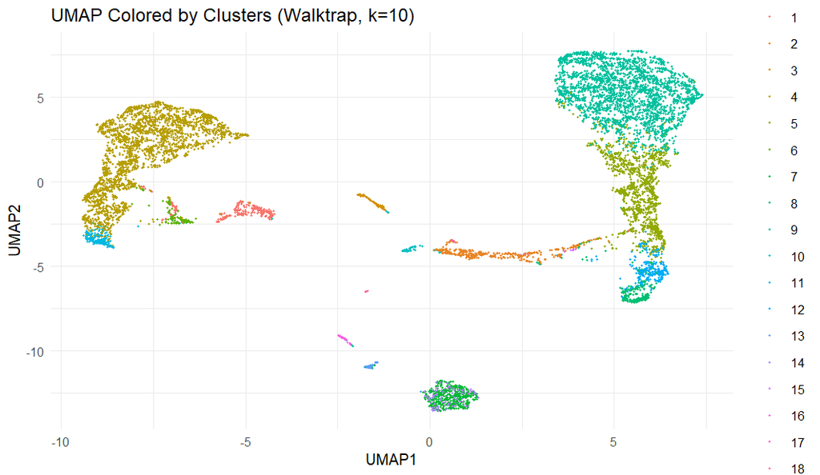

clusters umap

# 7.Cell Type Annotation:Using a cell annotation tool of your choice annotate the dataset and discuss:Concordance or discordance between clusters and predicted cell types,Evidence of heterogeneity or homogeneity within clusters

## using sindleR

BiocManager::install(“org.Hs.eg.db”) a ## selecting all library(org.Hs.eg.db) library(SingleCellExperiment)

## loading reference dataset

ensembl_ids <- rownames(sce)

## removing version numbers

ensembl_ids <- sub(“\..*”, ““, ensembl_ids)

## mapping Ensembl to symbols

gene_symbols <- mapIds( org.Hs.eg.db, keys = ensembl_ids, column = “SYMBOL”, keytype = “ENSEMBL”, multiVals = “first” )

## updating rownames

rownames(sce) <- gene_symbols

## filtering out genes with NA

sce <- sce[!is.na(rownames(sce)), ]

## running SingleR

library(celldex) library(SingleR) ref <- celldex::HumanPrimaryCellAtlasData() pred <- SingleR(test = sce, ref = ref, labels = ref$label.main) sce$predicted_cell_type <- pred$labels

## visualising the difference

library(ggplot2) umap_df <-as.data.frame(reducedDim(sce, “UMAP”)) umap_df$CellType <- sce$predicted_cell_type

ggplot(umap_df, aes(x = UMAP1, y = UMAP2, color = CellType)) + geom_point(size = 0.3, alpha = 1) + labs(title = “UMAP Colored by Predicted Cell Types”) + theme_minimal(10)

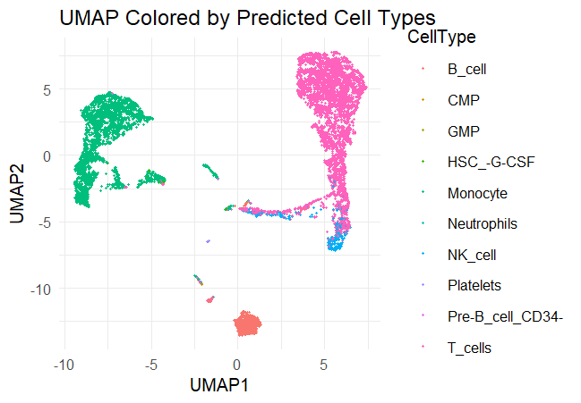

cell type umap

# 8.Tissue Origin Inference:Based on gene markers, annotation, and cluster structure, propose a hypothesis about the tissue of origin for the dataset. Justify your guess with biological reasoning.

## ensuring both columns are clean

markers_genes <- toupper(trimws(gtf$gene_symbol)) panglao_genes <- toupper(trimws(panglao$official.gene.symbol))

## matching by intersection

matched_genes <- intersect(markers_genes, panglao_genes)

## filtering PanglaoDB by matched genes

matched_table <- panglao[toupper(panglao$official.gene.symbol) %in% matched_genes, ]

## counting how many matched each cell type

celltype_counts <- as.data.frame(table(matched_table$cell.type)) celltype_counts <- celltype_counts[order(-celltype_counts$Freq), ] print(celltype_counts)

## plotting histogram

library(ggplot2) colnames(celltype_counts) <- c(“CellType”, “Count”)

ggplot(celltype_counts, aes(x = reorder(CellType, -Count), y = Count)) + geom_bar(stat = “identity”, fill = “purple”) + theme_minimal() + labs(title = “Cell Type Frequency (from PanglaoDB markers)”, x = “Cell Type”, y = “Number of Marker Genes”) + theme(axis.text.x = element_text(angle = 45, hjust = 1))

[figure not shown]

tissues

## they are too much to visualise, let’s see the top 25 tissues

library(ggplot2)

## selecting top 25 most frequent cell types

top25 <-head(celltype_counts[order(-celltype_counts$Count), ], 25)

## plotting histogram

ggplot(top25, aes(x = reorder(CellType, -Count), y = Count)) + geom_bar(stat = “identity”, fill = “yellow”) + theme_minimal() + labs(title = “Top 25 Cell Types by Marker Frequency”, x = “Cell Type”, y = “Number of Marker Genes”) + theme(axis.text.x = element_text(angle = 45, hjust = 1))

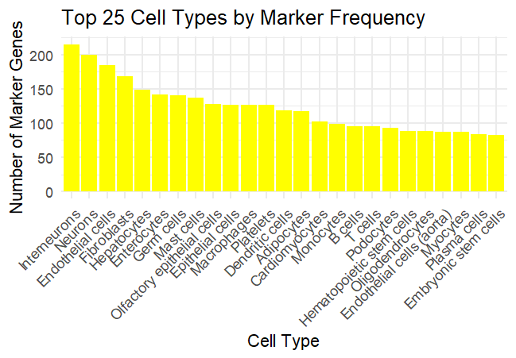

top 25 tissues